# Introduction to R for the Python User

## Exercise: tidy workflow for data analysis

The Department of Education collects [annual statistics on colleges and universities in the United States](https://collegescorecard.ed.gov/). I have included a subset of this data from 2018-19 in the [`rcfss`](https://github.com/uc-cfss/rcfss) library from GitHub. To install the package, run the command `devtools::install_github("uc-cfss/rcfss")` in the console.

> If you don’t already have the `devtools` library installed, you will get an error. Go back and install this first using `install.packages("devtools")`, then run `devtools::install_github("uc-cfss/rcfss")`.

```r
library(rcfss)
data("scorecard")
glimpse(scorecard)
## Rows: 1,753
## Columns: 14
## $ unitid    <int> 210492, 446048, 441982, 445692, 445708, 449658, 461528, 4809…
## $ name      <chr> "Bryn Athyn College of the New Church", "Ave Maria Universit…
## $ state     <chr> "PA", "FL", "MA", "UT", "NC", "NJ", "NC", "TX", "UT", "CA", …
## $ type      <fct> "Private, nonprofit", "Private, nonprofit", "Private, nonpro…
## $ admrate   <dbl> 0.888, 0.830, 0.157, 0.841, 0.857, 0.597, 0.923, 1.000, 0.71…
## $ satavg    <dbl> 1113, 1169, 1522, NA, NA, NA, NA, NA, NA, NA, 1105, 980, NA,…
## $ cost      <int> 30889, 34484, 70289, 33452, 47543, 16000, 16701, NA, 26040, …
## $ netcost   <dbl> 19048, 17981, 21370, 25270, 26835, 7975, 13543, NA, 22209, 1…
## $ avgfacsal <dbl> 65475, 68202, 110907, 84042, 84087, 41400, 19746, 37467, NA,…
## $ pctpell   <dbl> 0.4048, 0.2593, 0.0921, 0.5625, 0.5801, 0.4190, 0.2835, 0.47…
## $ comprate  <dbl> 0.556, 0.555, 0.926, 0.618, 0.572, 0.250, 0.615, NA, NA, NA,…
## $ firstgen  <dbl> 0.338, 0.176, NA, 0.304, 0.346, NA, NA, NA, 0.415, NA, NA, 0…
## $ debt      <dbl> 12000, 12000, 12537, 24500, 16500, NA, 9206, NA, 7500, NA, N…
## $ locale    <fct> Suburb, Rural, Suburb, City, City, City, City, Suburb, City,…
```

Type `?scorecard` in the console to open up the help file for this data set. This includes the documentation for all the variables.

### Generate a data frame of schools with a greater than 40% share of first-generation students

```r
filter(.data = scorecard, firstgen > .40)
## # A tibble: 352 × 14
##    unitid name       state type   admrate satavg  cost netcost avgfacsal pctpell
##     <int> <chr>      <chr> <fct>    <dbl>  <dbl> <int>   <dbl>     <dbl>   <dbl>
##  1 480985 Midwives … UT    Priva…   0.714     NA 26040   22209        NA   0.492
##  2 482422 DeVry Uni… AZ    Priva…   0.964     NA 34891   30562     60318   0.537
##  3 482468 DeVry Uni… GA    Priva…   0.946     NA 31704   26800     74214   0.584
##  4 482538 DeVry Uni… MO    Priva…   0.667     NA 24172   24172     73512   0.546
##  5 482608 DeVry Uni… PA    Priva…   1         NA 37432   32486     65232   0.583
##  6 482635 DeVry Uni… TX    Priva…   0.938     NA 35692   30179     68328   0.532
##  7 475732 Chamberla… GA    Priva…   0.188     NA    NA      NA     57222   0.529
##  8 487375 Arizona C… NV    Priva…   0.883     NA 36700   33488     66456   1
##  9 486938 Chamberla… NV    Priva…   0.571     NA 39475   36915     72810   0.481
## 10 484905 Universit… TX    Public   0.831    992 18699    7400     76851   0.615
## # … with 342 more rows, and 4 more variables: comprate <dbl>, firstgen <dbl>,
## #   debt <dbl>, locale <fct>
```

### Generate a data frame with the average SAT score for each type of college

```r
scorecard %>%
  group_by(type) %>%
  summarize(mean_sat = mean(satavg, na.rm = TRUE))
## # A tibble: 3 × 2
##   type                mean_sat
##   <fct>                  <dbl>
## 1 Public                 1129.
## 2 Private, nonprofit     1153.
## 3 Private, for-profit    1068.
```

### Calculate for each school how many students it takes to pay the average faculty member’s salary and generate a data frame with the school’s name and the calculated value

Note: use the net cost of attendance.

```r
scorecard %>%
  mutate(ratio = avgfacsal / netcost) %>%
  select(name, ratio)
## # A tibble: 1,753 × 2
##    name                                         ratio
##    <chr>                                        <dbl>
##  1 Bryn Athyn College of the New Church          3.44
##  2 Ave Maria University                          3.79
##  3 Franklin W Olin College of Engineering        5.19
##  4 Neumont College of Computer Science           3.33
##  5 Johnson & Wales University-Charlotte          3.13
##  6 Bais Medrash Toras Chesed                     5.19
##  7 Grace College of Divinity                     1.46
##  8 Gemini School of Visual Arts & Communication NA
##  9 Midwives College of Utah                     NA
## 10 Grace Mission University                      3.24
## # … with 1,743 more rows
```

### Calculate how many private, nonprofit schools have a smaller net cost than the University of Chicago

Hint: the result should be a data frame with one row for the University of Chicago, and a column containing the requested value.

##### Report the number as the total number of schools

```r
scorecard %>%
  filter(type == "Private, nonprofit") %>%
  arrange(netcost) %>%
  # use row_number() but subtract 1 since UChicago is not cheaper than itself
  mutate(school_cheaper = row_number() - 1) %>%
  filter(name == "University of Chicago") %>%
  glimpse()
## Rows: 1
## Columns: 15
## $ unitid         <int> 144050
## $ name           <chr> "University of Chicago"
## $ state          <chr> "IL"
## $ type           <fct> "Private, nonprofit"
## $ admrate        <dbl> 0.0726
## $ satavg         <dbl> 1520
## $ cost           <int> 75735
## $ netcost        <dbl> 26160
## $ avgfacsal      <dbl> 166221
## $ pctpell        <dbl> 0.109
## $ comprate       <dbl> 0.942
## $ firstgen       <dbl> 0.202
## $ debt           <dbl> 15000
## $ locale         <fct> City
## $ school_cheaper <dbl> 777
```

##### Report the number as the percentage of schools

```r
scorecard %>%
  filter(type == "Private, nonprofit") %>%
  mutate(netcost_rank = percent_rank(netcost)) %>%
  filter(name == "University of Chicago") %>%
  glimpse()
## Rows: 1
## Columns: 15
## $ unitid       <int> 144050
## $ name         <chr> "University of Chicago"
## $ state        <chr> "IL"
## $ type         <fct> "Private, nonprofit"
## $ admrate      <dbl> 0.0726
## $ satavg       <dbl> 1520
## $ cost         <int> 75735
## $ netcost      <dbl> 26160
## $ avgfacsal    <dbl> 166221
## $ pctpell      <dbl> 0.109
## $ comprate     <dbl> 0.942
## $ firstgen     <dbl> 0.202
## $ debt         <dbl> 15000
## $ locale       <fct> City
## $ netcost_rank <dbl> 0.714
```

## How do I model my data?

Tidying up data can be as calming and rewarding in the same way as knitting or rearranging the specimen jars on the shelves in your dining room-stroke-laboratory. Eventually, though, people want to do some statistics. The simplest tool for this in R is `lm`, which stands for “linear model”. Given a formula and a data set, it calculates coefficients to fit that formula to that data:

```r
lm(estimate ~ lo, data = infant_hiv)
##
## Call:
## lm(formula = estimate ~ lo, data = infant_hiv)
##
## Coefficients:
## (Intercept)           lo
##      0.0421       1.0707
```

This is telling us that `estimate` is more-or-less equal to `0.0421 + 1.0707 * lo`. The `~` symbol is used to separate the left and right sides of the equation, and as with all things tidyverse, lazy evaluation allows us to use variable names directly. In fact, it lets us write much more complex formulas involving functions of multiple variables. For example, we can regress `estimate` against the square roots of `lo` and `hi` (though there is no sound statistical reason to do so):

```r
lm(estimate ~ sqrt(lo) + sqrt(hi), data = infant_hiv)
##
## Call:
## lm(formula = estimate ~ sqrt(lo) + sqrt(hi), data = infant_hiv)
##
## Coefficients:
## (Intercept)     sqrt(lo)     sqrt(hi)
##      -0.222        0.618        0.481
```

One important thing to note here is the way that `+` is overloaded in formulas. The formula `estimate ~ lo + hi` does *not* mean “regress `estimate` against the sum of `lo` and `hi`”, but rather, “regress `estimate` against the two variables `lo` and `hi`”:

```r
lm(estimate ~ lo + hi, data = infant_hiv)
##
## Call:
## lm(formula = estimate ~ lo + hi, data = infant_hiv)
##
## Coefficients:
## (Intercept)           lo           hi
##     -0.0133       0.4298       0.5675
```

If we want to regress `estimate` against the average of `lo` and `hi` (i.e., regress `estimate` against a single calculated variable instead of against two variables) we need to create a temporary column:

```r
infant_hiv %>%
  mutate(ave_lo_hi = (lo + hi)/2) %>%
  lm(estimate ~ ave_lo_hi, data = .)
##
## Call:
## lm(formula = estimate ~ ave_lo_hi, data = .)
##
## Coefficients:
## (Intercept)    ave_lo_hi
##    -0.00897      1.01080
```

Here, the call to `lm` is using the variable `.` to mean “the data coming in from the previous stage of the pipeline”. Most of the functions in the tidyverse use this convention so that data can be passed to a function that expects it in a position other than the first.

### Alternative workflows for modeling

R does not have an extensive machine learning package such as `scikit-learn` which integrates the most common and advanced machine learning algorithms into a single package. This is partially because R has an extensive and decentralized developer base where anyone can write a package implementing a specific ML algorithm. Historically, R has been the development arena for new statistical and machine learning algorithms.

This can make it practically difficult to write code utilizing these methods when each package may use a different API to define a model. Consider three different packages which implement a random forest regression:

```r
# From randomForest
rf_1 <- randomForest(
  y ~ .,
  data = .,
  mtry = 10,
  ntree = 2000,
  importance = TRUE
)

# From ranger
rf_2 <- ranger(
  y ~ .,
  data = dat,
  mtry = 10,
  num.trees = 2000,
  importance = "impurity"
)

# From sparklyr
rf_3 <- ml_random_forest(
  dat,
  intercept = FALSE,
  response = "y",
  features = names(dat)[names(dat) != "y"],
  col.sample.rate = 10,
  num.trees = 2000
)
```

However, there are a few popular packages which act as wrappers around a common set of learners, providing a single, unified interface to a range of models.

- [`caret`](https://topepo.github.io/caret/)
- [`mlr3`](https://mlr3.mlr-org.com/)
- [`tidymodels`](https://www.tidymodels.org/)

## How do I create a plot?

Human being always want to see the previously unseen, though they are not always glad to have done so. The most popular tool for doing this in R is `ggplot2`, which implements and extends the patterns for creating charts described in @Wilk2005. Every chart it creates has a geometry that controls how data is displayed and a mapping that controls how values are represented geometrically. For example, these lines of code create a scatter plot showing the relationship between `lo` and `hi` values in the infant HIV data:

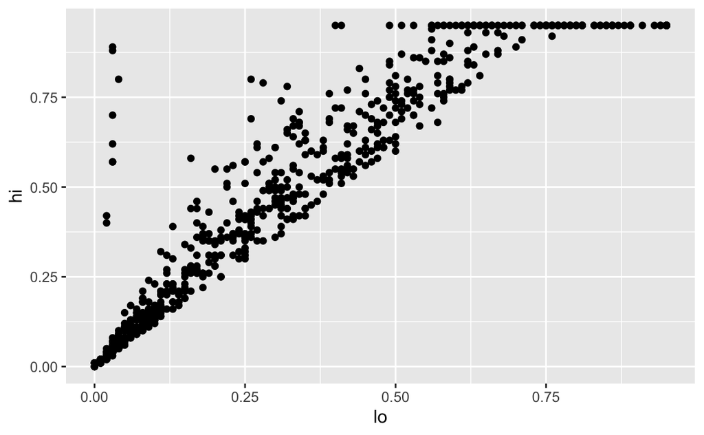

```r
ggplot(infant_hiv) + geom_point(mapping = aes(x = lo, y = hi))
```

Looking more closely:

- The function `ggplot` creates an object to represent the chart with `infant_hiv` as the underlying data.
- `geom_point` specifies the geometry we want (points).
- Its `mapping` argument is assigned an aesthetic that specifies `lo` is to be used as the `x` coordinate and `hi` is to be used as the `y` coordinate.
- The elements of the chart are combined with `+` rather than `%>%` for historical reasons.

Let’s create a slightly more appealing plot by dropping NAs, making the points semi-transparent, and colorizing them according to the value of `estimate`:

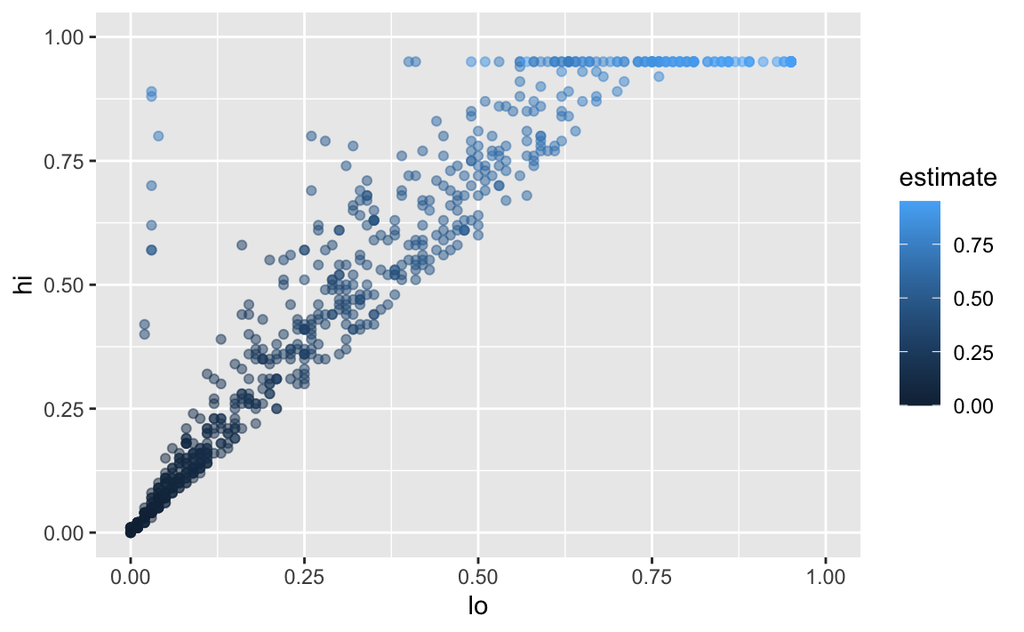

```r
infant_hiv %>%
  drop_na() %>%
  ggplot(mapping = aes(x = lo, y = hi, color = estimate)) +
  geom_point(alpha = 0.5) +
  xlim(0.0, 1.0) + ylim(0.0, 1.0)
```

We set the transparency `alpha` outside the aesthetic because its value is constant for all points. If we set it inside `aes(...)`, we would be telling ggplot2 to set the transparency according to the value of the data. We specify the limits to the axes manually with `xlim` and `ylim` to ensure that ggplot2 includes the upper bounds: without this, all of the data would be shown, but the upper label “1.00” would be omitted.

This plot immediately shows us that we have some outliers. There are far more values with `hi` equal to 0.95 than it seems there ought to be, and there are eight points running up the left margin that seem troubling as well. Let’s create a new tibble that doesn’t have these:

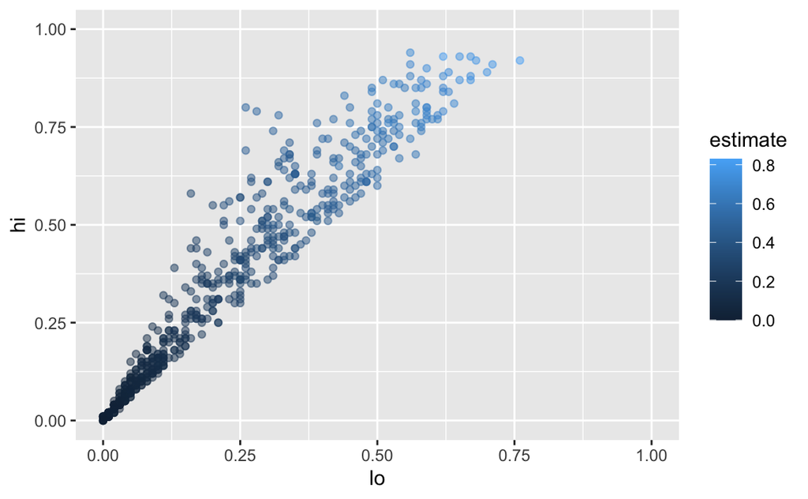

```r
infant_hiv %>%
  drop_na() %>%
  filter(hi != 0.95) %>%
  filter(!((lo < 0.10) & (hi > 0.25))) %>%
  ggplot(mapping = aes(x = lo, y = hi, color = estimate)) +
  geom_point(alpha = 0.5) +
  xlim(0.0, 1.0) + ylim(0.0, 1.0)
```

We can add the fitted curve by including another geometry called `geom_smooth`:

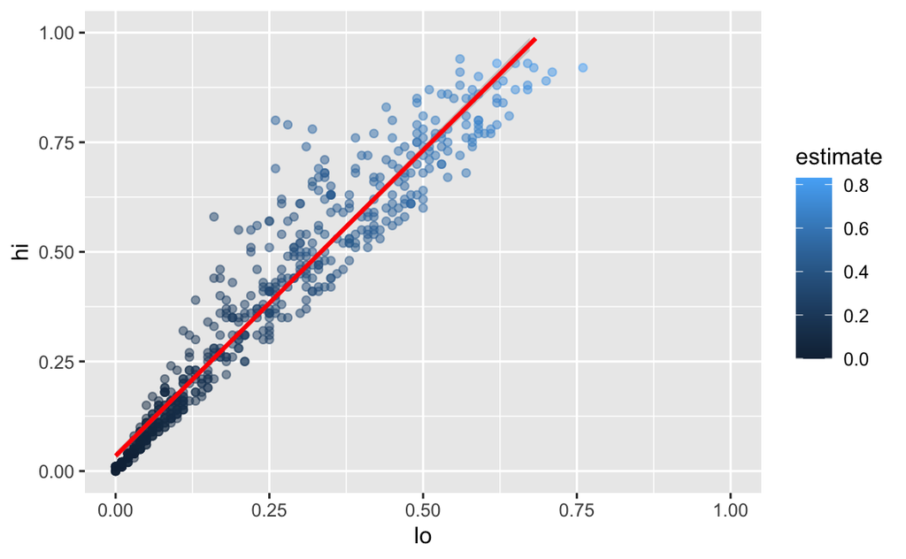

```r
infant_hiv %>%
  drop_na() %>%
  filter(hi != 0.95) %>%
  filter(!((lo < 0.10) & (hi > 0.25))) %>%
  ggplot(mapping = aes(x = lo, y = hi)) +
  geom_point(mapping = aes(color = estimate), alpha = 0.5) +
  geom_smooth(method = lm, color = 'red') +
  xlim(0.0, 1.0) + ylim(0.0, 1.0)
```

But wait: why is this complaining about missing values? Some online searches lead to the discovery that `geom_smooth` adds virtual points to the data for plotting purposes, some of which lie outside the range of the actual data, and that setting `xlim` and `ylim` then truncates these. (Remember, R is differently sane…) The safe way to control the range of the data is to add a call to `coord_cartesian`, which effectively zooms in on a region of interest:

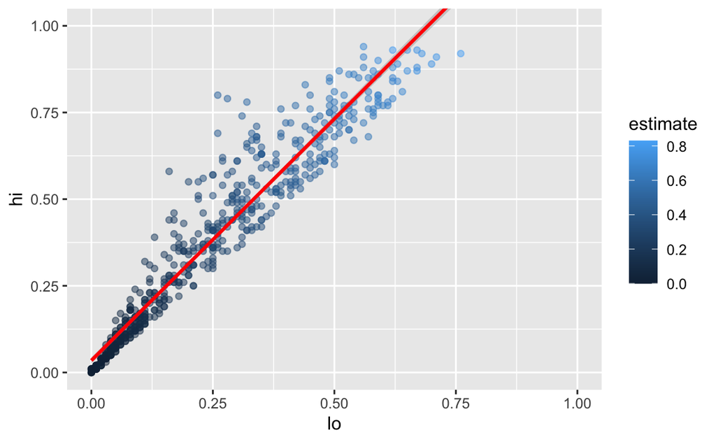

```r
infant_hiv %>%
  drop_na() %>%
  filter(hi != 0.95) %>%
  filter(!((lo < 0.10) & (hi > 0.25))) %>%
  ggplot(mapping = aes(x = lo, y = hi)) +
  geom_point(mapping = aes(color = estimate), alpha = 0.5) +
  geom_smooth(method = lm, color = 'red') +
  coord_cartesian(xlim = c(0.0, 1.0), ylim = c(0.0, 1.0))
```

## Exercise: creating graphs

Let’s practice generating layered graphics in R using data from [Gapminder World](https://www.gapminder.org/data/), which compiles country-level data on quality-of-life measures.

### Load the `gapminder` dataset

If you have not already installed the `gapminder` package and you try to load it using the following code, you will get an error:

```r
library(gapminder)
```

```
Error in library(gapminder) : there is no package called ‘gapminder’
```

If this happens, install the gapminder package by running `install.packages("gapminder")` in your console.

Once you’ve done this, load the gapminder package:

```r
library(gapminder)
glimpse(gapminder)
## Rows: 1,704
## Columns: 6
## $ country   <fct> "Afghanistan", "Afghanistan", "Afghanistan", "Afghanistan", …
## $ continent <fct> Asia, Asia, Asia, Asia, Asia, Asia, Asia, Asia, Asia, Asia, …
## $ year      <int> 1952, 1957, 1962, 1967, 1972, 1977, 1982, 1987, 1992, 1997, …
## $ lifeExp   <dbl> 28.8, 30.3, 32.0, 34.0, 36.1, 38.4, 39.9, 40.8, 41.7, 41.8, …
## $ pop       <int> 8425333, 9240934, 10267083, 11537966, 13079460, 14880372, 12…
## $ gdpPercap <dbl> 779, 821, 853, 836, 740, 786, 978, 852, 649, 635, 727, 975, …
```

### Generate a histogram of life expectancy

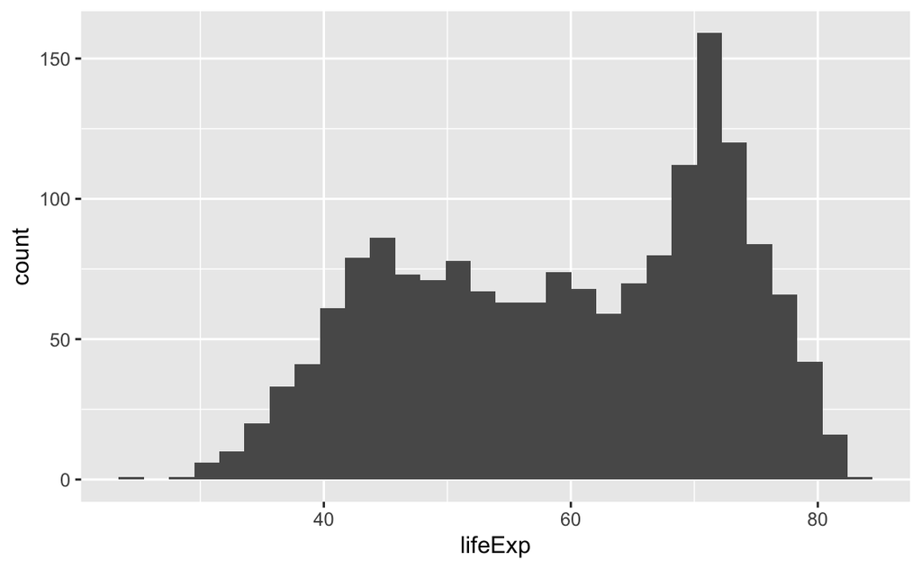

```r
ggplot(data = gapminder, mapping = aes(x = lifeExp)) +
  geom_histogram()
```

### Generate separate histograms of life expectancy for each continent

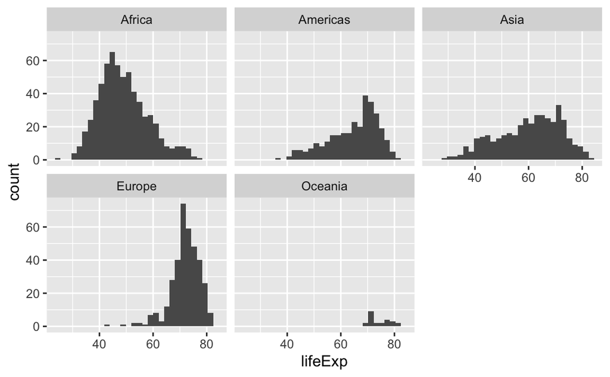

```r
ggplot(data = gapminder, mapping = aes(x = lifeExp)) +
  geom_histogram() +
  facet_wrap(facets = vars(continent))
```

### Compare the distribution of life expectancy, by continent by generating a boxplot

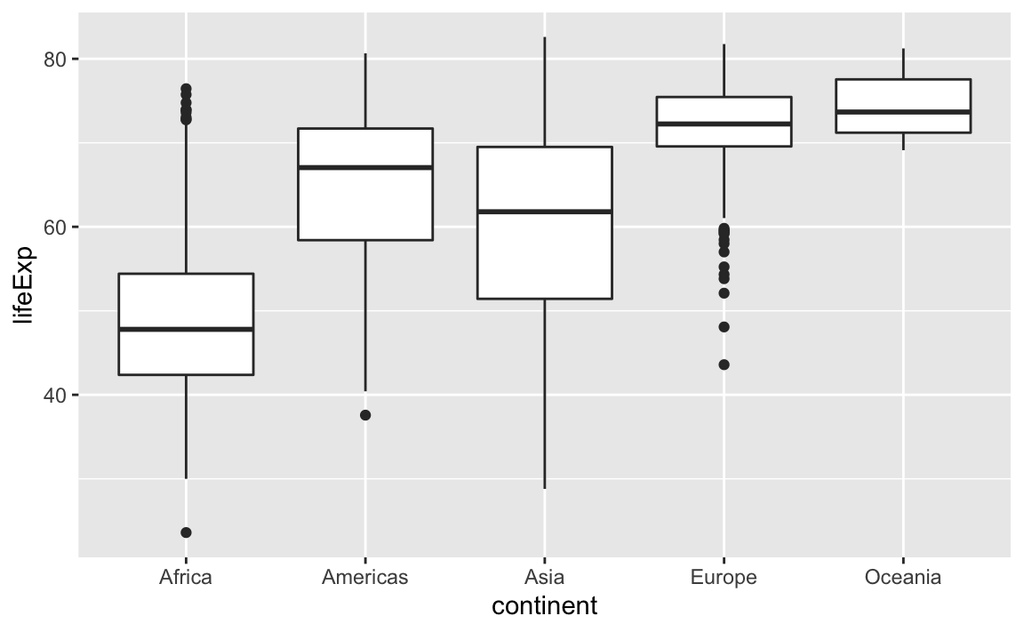

```r
ggplot(data = gapminder, mapping = aes(x = continent, y = lifeExp)) +
  geom_boxplot()
```

#### Redraw the plot, but this time use a violin plot

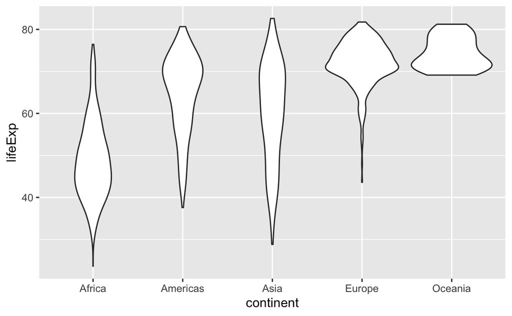

```r
ggplot(data = gapminder, mapping = aes(x = continent, y = lifeExp)) +
  geom_violin()
```

### Generate a scatterplot of the relationship between per capita GDP and life expectancy

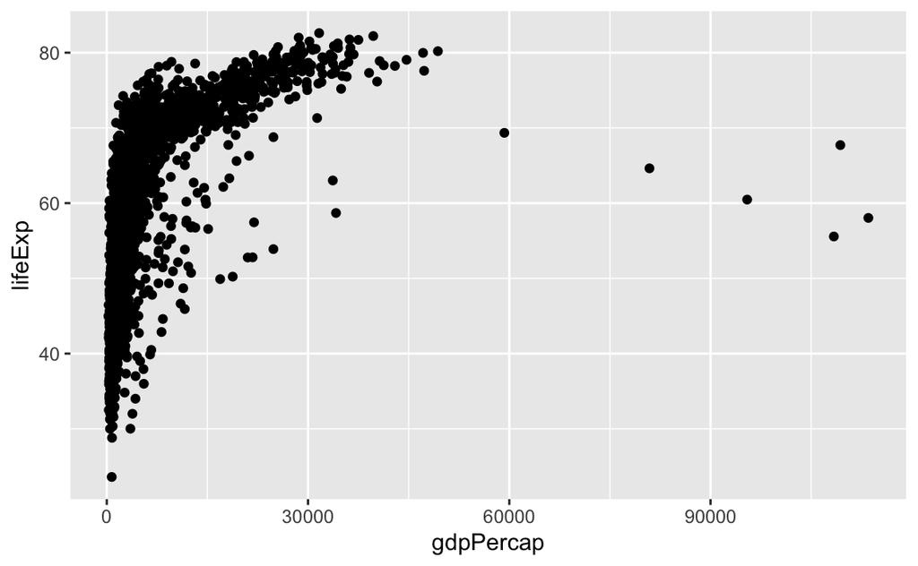

```r
ggplot(data = gapminder, mapping = aes(x = gdpPercap, y = lifeExp)) +
  geom_point()
```

#### Add a smoothing line to the scatterplot

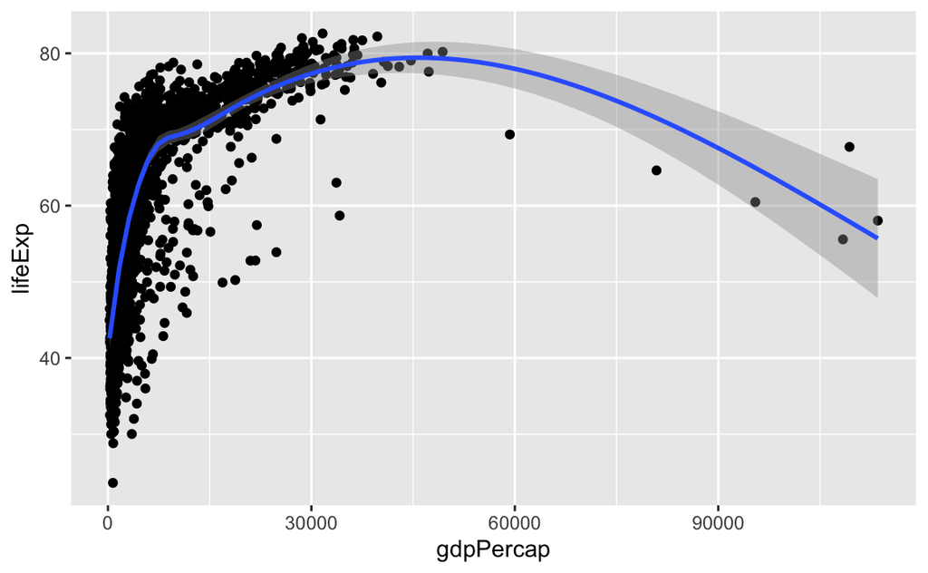

```r
ggplot(data = gapminder, mapping = aes(x = gdpPercap, y = lifeExp)) +
  geom_point() +
  geom_smooth()
```

# R Markdown vs. Jupyter Notebooks

> For more information on R Markdown documents and how to generate them, check out [last quarter’s workshop](https://css-skills.uchicago.edu/posts/2021-11-16-literate-programming-with-r-markdown/).

## Jupyter Notebooks

[figure not shown]

```r
include_graphics(path = "https://www.dataquest.io/wp-content/uploads/2019/01/interface-screenshot.png")
```

## R Markdown

````
---
title: "Gun deaths"
date: "`r lubridate::today()`"
output: html_document
---

```{r setup, include = FALSE}
knitr::opts_chunk$set(echo = TRUE)
```

```{r packages, cache = FALSE}
library(tidyverse)
# remotes::install_github("uc-cfss/rcfss) # if not already installed, run this code
library(rcfss)

theme_set(theme_minimal())
```

```{r youths}
youth <- gun_deaths %>%
  filter(age <= 65)
```

# Gun deaths by age

We have data about `r nrow(gun_deaths)` individuals killed by guns. Only `r nrow(gun_deaths) - nrow(youth)` are older than 65. The distribution of the remainder is shown below:

```{r youth-dist, echo = FALSE}
youth %>%
  ggplot(mapping = aes(age)) +
  geom_freqpoly(binwidth = 1)
```

# Gun deaths by race

```{r race-dist}
youth %>%
  ggplot(mapping = aes(fct_infreq(race) %>% fct_rev())) +
  geom_bar() +
  coord_flip() +
  labs(x = "Victim race")
```
````

## Major components

1. A **YAML header** surrounded by `---`s
2. **Chunks** of R code surounded by `` ``` ``
3. Text mixed with simple text formatting using the Markdown syntax

## Knitting process

```r
include_graphics(path = "https://r4ds.had.co.nz/images/RMarkdownFlow.png")
```

[output not shown]

# Running Python within R

R and Python can and should be friends! Beyond that, you can actually call Python from within R using a variety of technqiues, as well as translate between R and Python objects.

## `reticulate`

- [`reticulate`](https://rstudio.github.io/reticulate/)

## `keras`

- [R interface to Keras](https://keras.rstudio.com/)

# Acknowledgments

- This workshop is derived in part from [R for Data Engineers: A Brief Introduction for People Who Count From Zero](https://tidynomicon.github.io/tidynomicon/) by Greg Wilson and is licensed under the [Creative Commons Attribution 4.0 International license (CC-BY-4.0)](https://tidynomicon.github.io/tidynomicon/license.html).

# Session information

```r
sessioninfo::session_info()
## ─ Session info ───────────────────────────────────────────────────────────────
##  setting  value
##  version  R version 4.1.2 (2021-11-01)
##  os       macOS Monterey 12.1
##  system   aarch64, darwin20
##  ui       X11
##  language (EN)
##  collate  en_US.UTF-8
##  ctype    en_US.UTF-8
##  tz       America/Chicago
##  date     2022-01-25
##  pandoc   2.14.2 @ /usr/local/bin/ (via rmarkdown)
##
## ─ Packages ───────────────────────────────────────────────────────────────────
##  package     * version date (UTC) lib source
##  assertthat    0.2.1   2019-03-21 [1] CRAN (R 4.1.0)
##  backports     1.4.1   2021-12-13 [1] CRAN (R 4.1.1)
##  bit           4.0.4   2020-08-04 [1] CRAN (R 4.1.1)
##  bit64         4.0.5   2020-08-30 [1] CRAN (R 4.1.0)
##  broom         0.7.11  2022-01-03 [1] CRAN (R 4.1.2)
##  bslib         0.3.1   2021-10-06 [1] CRAN (R 4.1.1)
##  cellranger    1.1.0   2016-07-27 [1] CRAN (R 4.1.0)
##  cli           3.1.0   2021-10-27 [1] CRAN (R 4.1.1)
##  colorspace    2.0-2   2021-06-24 [1] CRAN (R 4.1.1)
##  crayon        1.4.2   2021-10-29 [1] CRAN (R 4.1.1)
##  DBI           1.1.2   2021-12-20 [1] CRAN (R 4.1.1)
##  dbplyr        2.1.1   2021-04-06 [1] CRAN (R 4.1.0)
##  digest        0.6.29  2021-12-01 [1] CRAN (R 4.1.1)
##  dplyr       * 1.0.7   2021-06-18 [1] CRAN (R 4.1.0)
##  ellipsis      0.3.2   2021-04-29 [1] CRAN (R 4.1.0)
##  evaluate      0.14    2019-05-28 [1] CRAN (R 4.1.0)
##  fansi         0.5.0   2021-05-25 [1] CRAN (R 4.1.0)
##  farver        2.1.0   2021-02-28 [1] CRAN (R 4.1.0)
##  fastmap       1.1.0   2021-01-25 [1] CRAN (R 4.1.0)
##  forcats     * 0.5.1   2021-01-27 [1] CRAN (R 4.1.1)
##  fs            1.5.2   2021-12-08 [1] CRAN (R 4.1.1)
##  gapminder   * 0.3.0   2017-10-31 [1] CRAN (R 4.1.0)
##  generics      0.1.1   2021-10-25 [1] CRAN (R 4.1.1)
##  ggplot2     * 3.3.5   2021-06-25 [1] CRAN (R 4.1.1)
##  glue        * 1.6.0   2021-12-17 [1] CRAN (R 4.1.1)
##  gtable        0.3.0   2019-03-25 [1] CRAN (R 4.1.1)
##  haven         2.4.3   2021-08-04 [1] CRAN (R 4.1.1)
##  here        * 1.0.1   2020-12-13 [1] CRAN (R 4.1.0)
##  highr         0.9     2021-04-16 [1] CRAN (R 4.1.0)
##  hms           1.1.1   2021-09-26 [1] CRAN (R 4.1.1)
##  htmltools     0.5.2   2021-08-25 [1] CRAN (R 4.1.1)
##  httr          1.4.2   2020-07-20 [1] CRAN (R 4.1.0)
##  jquerylib     0.1.4   2021-04-26 [1] CRAN (R 4.1.0)
##  jsonlite      1.7.2   2020-12-09 [1] CRAN (R 4.1.0)
##  knitr       * 1.37    2021-12-16 [1] CRAN (R 4.1.1)
##  labeling      0.4.2   2020-10-20 [1] CRAN (R 4.1.0)
##  lattice       0.20-45 2021-09-22 [1] CRAN (R 4.1.2)
##  lifecycle     1.0.1   2021-09-24 [1] CRAN (R 4.1.1)
##  lubridate     1.8.0   2021-10-07 [1] CRAN (R 4.1.1)
##  magrittr      2.0.1   2020-11-17 [1] CRAN (R 4.1.0)
##  Matrix        1.3-4   2021-06-01 [1] CRAN (R 4.1.2)
##  mgcv          1.8-38  2021-10-06 [1] CRAN (R 4.1.2)
##  modelr        0.1.8   2020-05-19 [1] CRAN (R 4.1.0)
##  munsell       0.5.0   2018-06-12 [1] CRAN (R 4.1.0)
##  nlme          3.1-153 2021-09-07 [1] CRAN (R 4.1.2)
##  pillar        1.6.4   2021-10-18 [1] CRAN (R 4.1.1)
##  pkgconfig     2.0.3   2019-09-22 [1] CRAN (R 4.1.0)
##  png           0.1-7   2013-12-03 [1] CRAN (R 4.1.0)
##  purrr       * 0.3.4   2020-04-17 [1] CRAN (R 4.1.0)
##  R6            2.5.1   2021-08-19 [1] CRAN (R 4.1.1)
##  rcfss       * 0.2.1   2022-01-06 [1] local
##  Rcpp          1.0.7   2021-07-07 [1] CRAN (R 4.1.0)
##  readr       * 2.1.1   2021-11-30 [1] CRAN (R 4.1.1)
##  readxl        1.3.1   2019-03-13 [1] CRAN (R 4.1.0)
##  reprex        2.0.1   2021-08-05 [1] CRAN (R 4.1.1)
##  reticulate  * 1.23    2022-01-14 [1] CRAN (R 4.1.1)
##  rlang       * 0.4.12  2021-10-18 [1] CRAN (R 4.1.1)
##  rmarkdown     2.11    2021-09-14 [1] CRAN (R 4.1.1)
##  rprojroot     2.0.2   2020-11-15 [1] CRAN (R 4.1.0)
##  rstudioapi    0.13    2020-11-12 [1] CRAN (R 4.1.0)
##  rvest         1.0.2   2021-10-16 [1] CRAN (R 4.1.1)
##  sass          0.4.0   2021-05-12 [1] CRAN (R 4.1.0)
##  scales        1.1.1   2020-05-11 [1] CRAN (R 4.1.0)
##  sessioninfo   1.2.2   2021-12-06 [1] CRAN (R 4.1.1)
##  stringi       1.7.6   2021-11-29 [1] CRAN (R 4.1.1)
##  stringr     * 1.4.0   2019-02-10 [1] CRAN (R 4.1.1)
##  tibble      * 3.1.6   2021-11-07 [1] CRAN (R 4.1.1)
##  tidyr       * 1.1.4   2021-09-27 [1] CRAN (R 4.1.1)
##  tidyselect    1.1.1   2021-04-30 [1] CRAN (R 4.1.0)
##  tidyverse   * 1.3.1   2021-04-15 [1] CRAN (R 4.1.0)
##  tzdb          0.2.0   2021-10-27 [1] CRAN (R 4.1.1)
##  utf8          1.2.2   2021-07-24 [1] CRAN (R 4.1.0)
##  vctrs         0.3.8   2021-04-29 [1] CRAN (R 4.1.0)
##  vroom         1.5.7   2021-11-30 [1] CRAN (R 4.1.1)
##  withr         2.4.3   2021-11-30 [1] CRAN (R 4.1.1)
##  xfun          0.29    2021-12-14 [1] CRAN (R 4.1.1)
##  xml2          1.3.3   2021-11-30 [1] CRAN (R 4.1.1)
##  yaml          2.2.1   2020-02-01 [1] CRAN (R 4.1.0)
##
##  [1] /Library/Frameworks/R.framework/Versions/4.1-arm64/Resources/library
##
## ─ Python configuration ───────────────────────────────────────────────────────
##  python:         /Users/soltoffbc/Library/r-miniconda-arm64/envs/r-reticulate/bin/python
##  libpython:      /Users/soltoffbc/Library/r-miniconda-arm64/envs/r-reticulate/lib/libpython3.8.dylib
##  pythonhome:     /Users/soltoffbc/Library/r-miniconda-arm64/envs/r-reticulate:/Users/soltoffbc/Library/r-miniconda-arm64/envs/r-reticulate
##  version:        3.8.12 | packaged by conda-forge | (default, Oct 12 2021, 21:25:50)  [Clang 11.1.0 ]
##  numpy:          /Users/soltoffbc/Library/r-miniconda-arm64/envs/r-reticulate/lib/python3.8/site-packages/numpy
##  numpy_version:  1.22.0
##
##  NOTE: Python version was forced by RETICULATE_PYTHON
##
## ──────────────────────────────────────────────────────────────────────────────
```